# Fetal Health Classification

Aloui Ameni Roua Riahi

2023-05-19

** Description of Dataset **

This dataset contains 2126 records of features extracted from Cardiotocogram exams, which were then classified by expert obstetrician into 3 classes: “Normal”, “Suspect” and “Pathological”. The features included in this study are the following:

baseline value: Baseline Fetal Heart Rate (FHR) (beats per minute) accelerations: Number of accelerations per second fetal_movement: Number of fetal movements per second uterine_contractions: Number of uterine contractions per second light_decelerations: Number of light decelerations (LDs) per second severe_decelerations: Number of severe decelerations (SDs) per second prolongued_decelerations: Number of prolonged decelerations (PDs) per second abnormal_short_term_variability: Percentage of time with abnormal short term variability mean_value_of_short_term_variability: Mean value of short term variability percentage_of_time_with_abnormal_long_term_variability: Percentage of time with abnormal long term variability mean_value_of_long_term_variability: Mean value of long term variability histogram_width: Width of histogram made using all values from a record histogram_min: Histogram minimum value histogram_max: Histogram maximum value histogram_number_of_peaks: Number of peaks in the exam histogram histogram_number_of_zeroes: Number of zeros in the exam histogram histogram_mode: Histogram mode histogram_mean: Histogram mean histogram_median: Histogram median histogram_variance: Histogram variance histogram_tendency: Histogram tendency fetal_health: Encoded as 1-Normal; 2-Suspect; 3-Pathological Which is our target column.

```r
library(tidyverse)
library(kableExtra)
library(skimr)
```

```r
library(corrplot)
library(e1071)
library(caret)
library(gbm)
library(MASS)
library(ggplot2)
```

```r
data=read.csv("C://Users//aloui//OneDrive//Bureau//Ameni//R//projetFoetus//Projet//fetal_health.csv",sep=',',dec='.')
View(data)
head(data)
```

```
##   baseline.value accelerations fetal_movement uterine_contractions
## 1            120         0.000              0                0.000
## 2            132         0.006              0                0.006
## 3            133         0.003              0                0.008
## 4            134         0.003              0                0.008
## 5            132         0.007              0                0.008
## 6            134         0.001              0                0.010
##   light_decelerations severe_decelerations prolongued_decelerations
## 1               0.000                    0                    0.000
## 2               0.003                    0                    0.000
## 3               0.003                    0                    0.000
## 4               0.003                    0                    0.000
## 5               0.000                    0                    0.000
## 6               0.009                    0                    0.002
##   abnormal_short_term_variability mean_value_of_short_term_variability
```

[output cut: 41 more lines]

** Data cleansing **

First of all we’ll be checking if there are any missing values or categorical variables.

```r
str(data)
```

```
## 'data.frame':    2126 obs. of  22 variables:
##  $ baseline.value                                        : num  120 132 133 134 132 134 134 122 122 122 ...
##  $ accelerations                                         : num  0 0.006 0.003 0.003 0.007 0.001 0.001 0 0 0 ...
##  $ fetal_movement                                        : num  0 0 0 0 0 0 0 0 0 0 ...
##  $ uterine_contractions                                  : num  0 0.006 0.008 0.008 0.008 0.01 0.013 0 0.002 0.003 ...
##  $ light_decelerations                                   : num  0 0.003 0.003 0.003 0 0.009 0.008 0 0 0 ...
##  $ severe_decelerations                                  : num  0 0 0 0 0 0 0 0 0 0 ...
##  $ prolongued_decelerations                              : num  0 0 0 0 0 0.002 0.003 0 0 0 ...
##  $ abnormal_short_term_variability                       : num  73 17 16 16 16 26 29 83 84 86 ...
##  $ mean_value_of_short_term_variability                  : num  0.5 2.1 2.1 2.4 2.4 5.9 6.3 0.5 0.5 0.3 ...
##  $ percentage_of_time_with_abnormal_long_term_variability: num  43 0 0 0 0 0 0 6 5 6 ...
##  $ mean_value_of_long_term_variability                   : num  2.4 10.4 13.4 23 19.9 0 0 15.6 13.6 10.6 ...
##  $ histogram_width                                       : num  64 130 130 117 117 150 150 68 68 68 ...
##  $ histogram_min                                         : num  62 68 68 53 53 50 50 62 62 62 ...
##  $ histogram_max                                         : num  126 198 198 170 170 200 200 130 130 130 ...
##  $ histogram_number_of_peaks                             : num  2 6 5 11 9 5 6 0 0 1 ...
##  $ histogram_number_of_zeroes                            : num  0 1 1 0 0 3 3 0 0 0 ...
##  $ histogram_mode                                        : num  120 141 141 137 137 76 71 122 122 122 ...
##  $ histogram_mean                                        : num  137 136 135 134 136 107 107 122 122 122 ...
##  $ histogram_median                                      : num  121 140 138 137 138 107 106 123 123 123 ...
##  $ histogram_variance                                    : num  73 12 13 13 11 170 215 3 3 1 ...
##  $ histogram_tendency                                    : num  1 0 0 1 1 0 0 1 1 1 ...
##  $ fetal_health                                          : num  2 1 1 1 1 3 3 3 3 3 ...
```

```r
colSums(is.na(data))
```

```
##                                         baseline.value
##                                                      0
##                                          accelerations
##                                                      0
##                                         fetal_movement
##                                                      0
##                                   uterine_contractions
##                                                      0
##                                    light_decelerations
##                                                      0
##                                   severe_decelerations
##                                                      0
##                               prolongued_decelerations
##                                                      0
##                        abnormal_short_term_variability
##                                                      0
##                   mean_value_of_short_term_variability
##                                                      0
## percentage_of_time_with_abnormal_long_term_variability
##                                                      0
##                    mean_value_of_long_term_variability
##                                                      0
##                                        histogram_width
##                                                      0
##                                          histogram_min
##                                                      0
##                                          histogram_max
##                                                      0
##                              histogram_number_of_peaks
##                                                      0
##                             histogram_number_of_zeroes
##                                                      0
##                                         histogram_mode
##                                                      0
##                                         histogram_mean
##                                                      0
##                                       histogram_median
##                                                      0
##                                     histogram_variance
##                                                      0
##                                     histogram_tendency
##                                                      0
##                                           fetal_health
##                                                      0
```

All of the variables are numeric, we’ll be transforming our target into factor.There is no missing value.

```r
data$fetal_health=as.factor(data$fetal_health)
str(data$fetal_health)
```

```
##  Factor w/ 3 levels "1","2","3": 2 1 1 1 1 3 3 3 3 3 ...
```

** Exploratory Data Analysis **

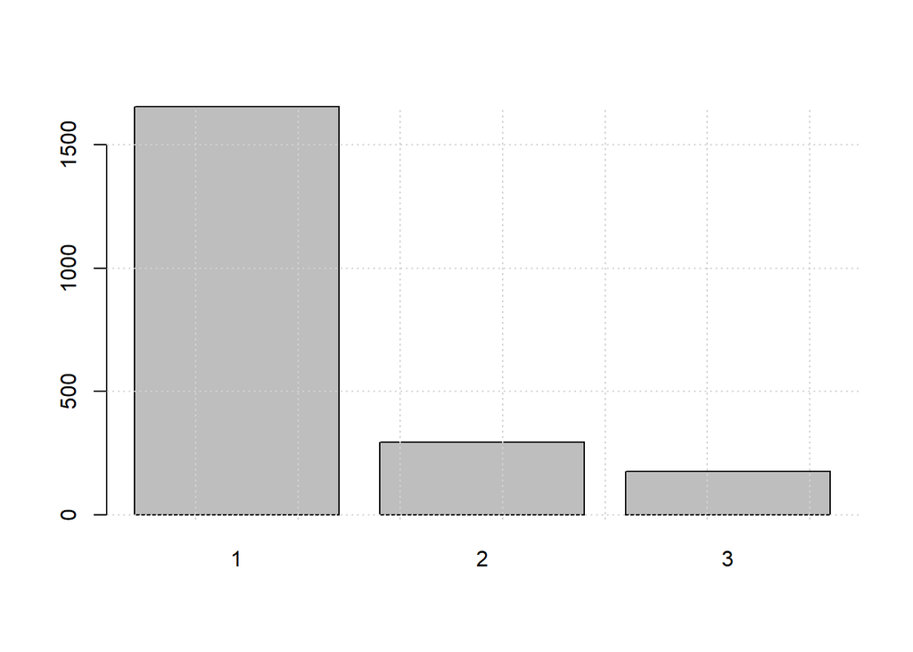

```r
target <- 'fetal_health'
data[,target] <- as.factor(data[,target])
plot(data[,target])
grid()
```

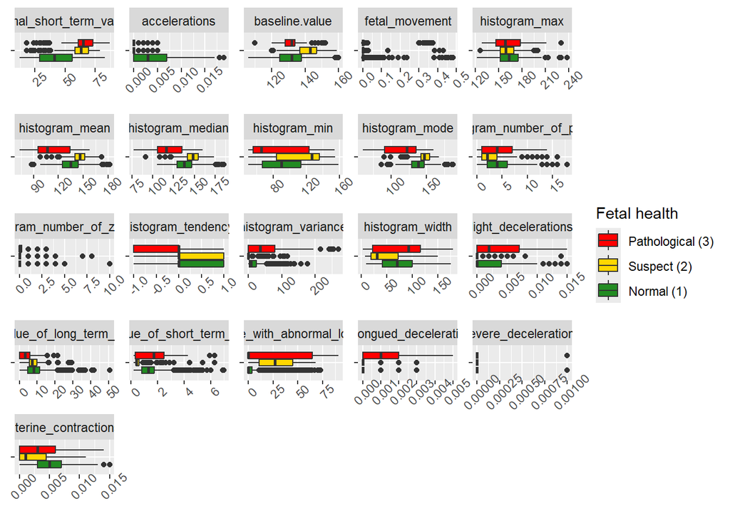

```r
data_long <- gather(data, key = 'variable', value = 'value', -fetal_health)

# Créer le graphique
ggplot(data_long, aes(x = '', y = value, fill = fetal_health)) +
  facet_wrap(~ variable, scales = 'free') +
  geom_boxplot() +
  coord_flip() +
  labs(x = NULL, y = NULL) +
  theme(axis.text.x = element_text(angle = 45)) +
  scale_fill_manual(name = 'Fetal health',
                    guide = guide_legend(reverse = TRUE),
                    labels = c('Normal (1)', 'Suspect (2)', 'Pathological (3)'),
                    values = c('forestgreen', 'gold', 'red'))
```

Correlation

```r
library(corrgram)
```

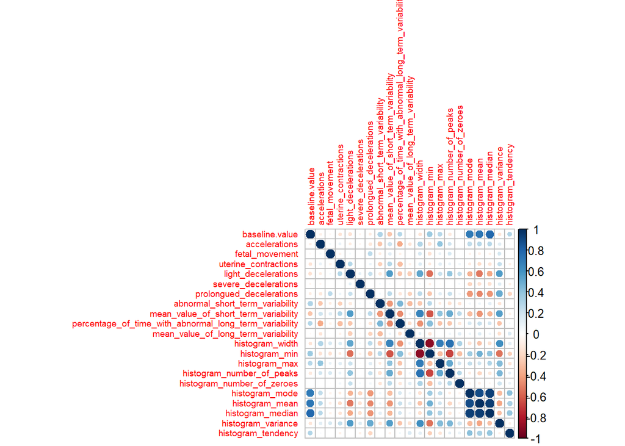

```r
library(corrplot)
x <- data[, sapply(data, is.numeric)]
corr=cor(x)
corrplot(corr, method="circle",tl.cex=0.6)
```

From figures, we can find “histogram_mean”, “histogram_mode” and “histogram_median” have high correlations value. We also notice a high correlation between these three and “baseline.value”. Moreover, “histogram_width” has high correlation with “histogram_max” and “histogram_number_of_peaks”.

** Data Standardization **

Before strating we will do a feature standardization to helps adjust all data elements to a common scale in order to improve the performance of PCA and prediction.

```r
data_new=scale(data[,-22])
head(data_new,2)
```

```
##      baseline.value accelerations fetal_movement uterine_contractions
## [1,]     -1.3519020    -0.8221949     -0.2031618           -1.4821159
## [2,]     -0.1324944     0.7299611     -0.2031618            0.5544962
##      light_decelerations severe_decelerations prolongued_decelerations
## [1,]          -0.6382874          -0.05746208               -0.2686911
## [2,]           0.3751547          -0.05746208               -0.2686911
##      abnormal_short_term_variability mean_value_of_short_term_variability
## [1,]                        1.512834                           -0.9428732
## [2,]                       -1.744341                            0.8686362
##      percentage_of_time_with_abnormal_long_term_variability
## [1,]                                              1.8021175
## [2,]                                             -0.5352354
##      mean_value_of_long_term_variability histogram_width histogram_min
## [1,]                          -1.0283184      -0.1654677    -1.0683107
## [2,]                           0.3930835       1.5287648    -0.8653352
##      histogram_max histogram_number_of_peaks histogram_number_of_zeroes
## [1,]     -2.119093                -0.7012319                 -0.4583360
## [2,]      1.893349                 0.6549828                  0.9579755
##      histogram_mode histogram_mean histogram_median histogram_variance
## [1,]     -1.0653632     0.15323366       -1.1813642          1.8701287
## [2,]      0.2165872     0.08910477        0.1320069         -0.2349429
##      histogram_tendency
## [1,]          1.1127182
## [2,]         -0.5244022
```

```r
data=data.frame(data_new,data[22])
View(data)
str(data)
```

```
## 'data.frame':    2126 obs. of  22 variables:
##  $ baseline.value                                        : num  -1.3519 -0.1325 -0.0309 0.0707 -0.1325 ...
##  $ accelerations                                         : num  -0.8222 0.73 -0.0461 -0.0461 0.9887 ...
##  $ fetal_movement                                        : num  -0.203 -0.203 -0.203 -0.203 -0.203 ...
##  $ uterine_contractions                                  : num  -1.482 0.554 1.233 1.233 1.233 ...
##  $ light_decelerations                                   : num  -0.638 0.375 0.375 0.375 -0.638 ...
##  $ severe_decelerations                                  : num  -0.0575 -0.0575 -0.0575 -0.0575 -0.0575 ...
##  $ prolongued_decelerations                              : num  -0.269 -0.269 -0.269 -0.269 -0.269 ...
##  $ abnormal_short_term_variability                       : num  1.51 -1.74 -1.8 -1.8 -1.8 ...
##  $ mean_value_of_short_term_variability                  : num  -0.943 0.869 0.869 1.208 1.208 ...
##  $ percentage_of_time_with_abnormal_long_term_variability: num  1.802 -0.535 -0.535 -0.535 -0.535 ...
##  $ mean_value_of_long_term_variability                   : num  -1.028 0.393 0.926 2.632 2.081 ...
##  $ histogram_width                                       : num  -0.165 1.529 1.529 1.195 1.195 ...
##  $ histogram_min                                         : num  -1.068 -0.865 -0.865 -1.373 -1.373 ...
##  $ histogram_max                                         : num  -2.119 1.893 1.893 0.333 0.333 ...
##  $ histogram_number_of_peaks                             : num  -0.701 0.655 0.316 2.35 1.672 ...
##  $ histogram_number_of_zeroes                            : num  -0.458 0.958 0.958 -0.458 -0.458 ...
##  $ histogram_mode                                        : num  -1.0654 0.2166 0.2166 -0.0276 -0.0276 ...
##  $ histogram_mean                                        : num  0.1532 0.0891 0.025 -0.0392 0.0891 ...
##  $ histogram_median                                      : num  -1.18136 0.13201 -0.00624 -0.07537 -0.00624 ...
##  $ histogram_variance                                    : num  1.87 -0.235 -0.2 -0.2 -0.269 ...
##  $ histogram_tendency                                    : num  1.113 -0.524 -0.524 1.113 1.113 ...
##  $ fetal_health                                          : Factor w/ 3 levels "1","2","3": 2 1 1 1 1 3 3 3 3 3 ...
```

** Principal Component Analysis(PCA) **

We removed the fetal_health column which is not necessary for the PCA.

```r
library(FactoMineR)
pca.data=PCA(data_new,graph = FALSE)
pca.data$eig
```

```
##           eigenvalue percentage of variance cumulative percentage of variance
## comp 1  6.058351e+00           2.884929e+01                          28.84929
## comp 2  3.507779e+00           1.670371e+01                          45.55300
## comp 3  1.824323e+00           8.687251e+00                          54.24025
## comp 4  1.496719e+00           7.127233e+00                          61.36749
## comp 5  1.218359e+00           5.801710e+00                          67.16920
## comp 6  1.020172e+00           4.857964e+00                          72.02716
## comp 7  9.817713e-01           4.675101e+00                          76.70226
## comp 8  9.265325e-01           4.412059e+00                          81.11432
## comp 9  7.624281e-01           3.630610e+00                          84.74493
## comp 10 6.402046e-01           3.048593e+00                          87.79352
## comp 11 5.772840e-01           2.748972e+00                          90.54250
## comp 12 4.973146e-01           2.368165e+00                          92.91066
## comp 13 3.885029e-01           1.850014e+00                          94.76067
## comp 14 3.270316e-01           1.557293e+00                          96.31797
## comp 15 2.654308e-01           1.263956e+00                          97.58192
## comp 16 1.808173e-01           8.610346e-01                          98.44296
## comp 17 1.331473e-01           6.340349e-01                          99.07699
## comp 18 1.175281e-01           5.596576e-01                          99.63665
## comp 19 4.951429e-02           2.357824e-01                          99.87243
## comp 20 2.678914e-02           1.275673e-01                         100.00000
## comp 21 6.738687e-31           3.208899e-30                         100.00000
```

```r
library(factoextra)
```

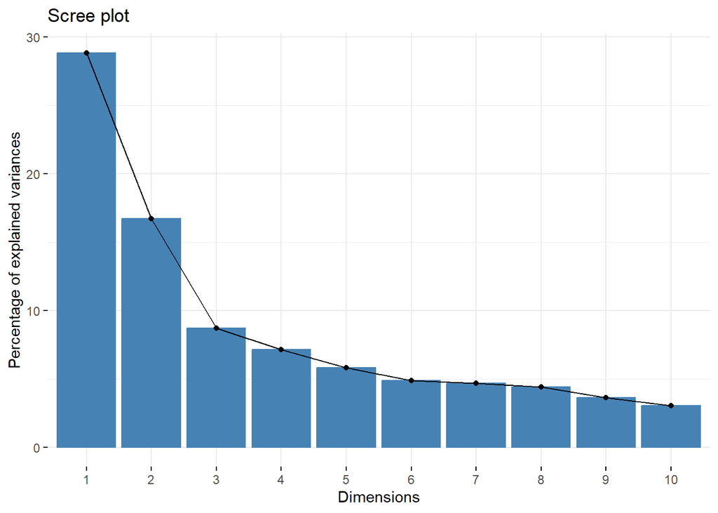

```r
fviz_screeplot(pca.data)
```

We are going to choose the elbow criterion for the choice of the number of dimensions, the offset is between the 3rd and the 4th component, we will then retain the first 3 components.

- Study of variables *

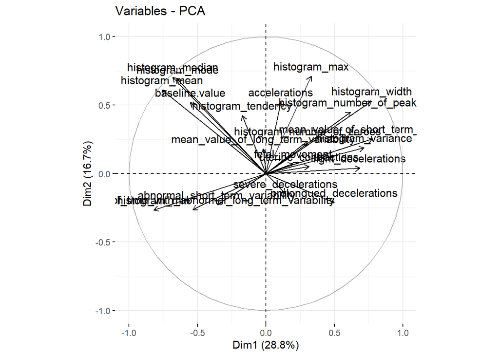

```r
fviz_pca_var(pca.data,c(1,2))
```

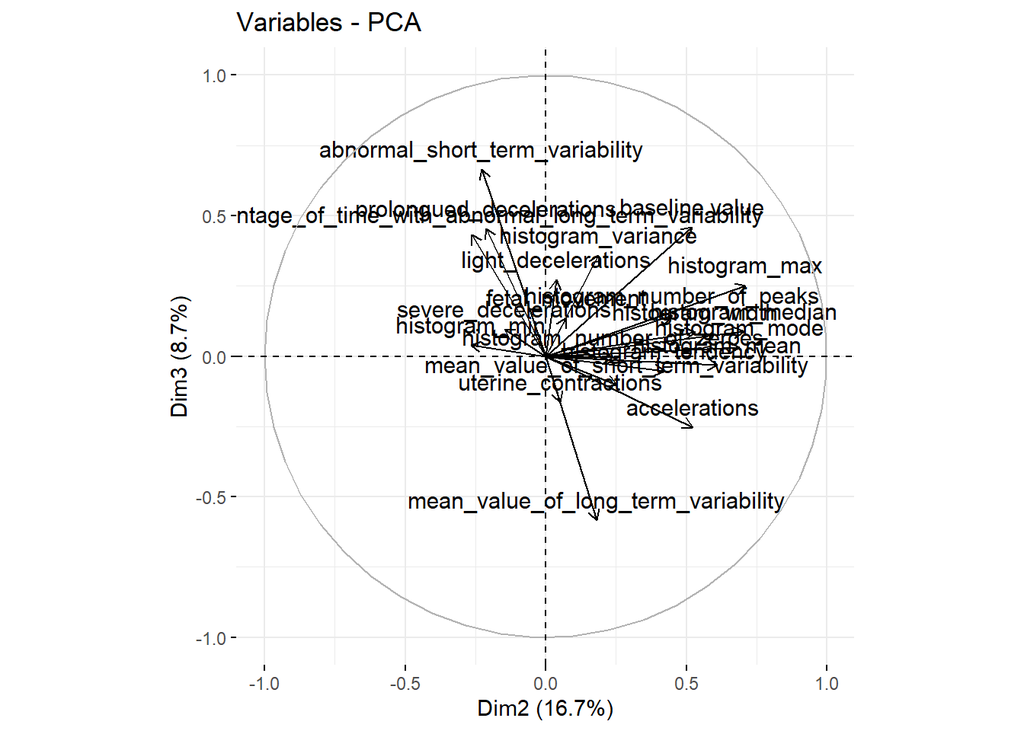

```r
fviz_pca_var(pca.data,c(2,3))
```

```r
pca.data$var$coord
```

```
##                                                              Dim.1       Dim.2
## baseline.value                                         -0.55170604  0.51938783
## accelerations                                           0.10688024  0.52186051
## fetal_movement                                          0.19849680  0.07196680
## uterine_contractions                                    0.31357289  0.05092868
## light_decelerations                                     0.68584463  0.03860582
## severe_decelerations                                    0.14212957 -0.14658120
## prolongued_decelerations                                0.49920703 -0.21279026
## abnormal_short_term_variability                        -0.35817465 -0.22904264
## mean_value_of_short_term_variability                    0.77851901  0.25286289
## percentage_of_time_with_abnormal_long_term_variability -0.53427054 -0.26372610
## mean_value_of_long_term_variability                    -0.01982373  0.18050404
## histogram_width                                         0.77176907  0.52976871
## histogram_min                                          -0.81736571 -0.26676464
## histogram_max                                           0.32898099  0.71064187
## histogram_number_of_peaks                               0.61814790  0.44947897
## histogram_number_of_zeroes                              0.30317904  0.23803990
## histogram_mode                                         -0.64627581  0.68780360
## histogram_mean                                         -0.76010845  0.60997211
## histogram_median                                       -0.67935431  0.70450845
## histogram_variance                                      0.71547462  0.18754894
## histogram_tendency                                     -0.17314319  0.42301768
##                                                               Dim.3
## baseline.value                                          0.459330502
## accelerations                                          -0.252361462
## fetal_movement                                          0.137366465
## uterine_contractions                                   -0.163197554
## light_decelerations                                     0.271264004
## severe_decelerations                                    0.096074125
## prolongued_decelerations                                0.454834232
## abnormal_short_term_variability                         0.664191242
## mean_value_of_short_term_variability                   -0.100748467
## percentage_of_time_with_abnormal_long_term_variability  0.433070735
## mean_value_of_long_term_variability                    -0.583723540
## histogram_width                                         0.086293271
## histogram_min                                           0.039281727
## histogram_max                                           0.252047715
## histogram_number_of_peaks                               0.145237378
## histogram_number_of_zeroes                             -0.005094553
## histogram_mode                                          0.031431926
```

[output cut: 33 more lines]

```
## prolongued_decelerations                               -0.312068622
## abnormal_short_term_variability                         0.057858188
## mean_value_of_short_term_variability                    0.077856287
## percentage_of_time_with_abnormal_long_term_variability -0.006580107
## mean_value_of_long_term_variability                    -0.211120917
## histogram_width                                        -0.064228394
## histogram_min                                           0.042105296
## histogram_max                                          -0.070073967
## histogram_number_of_peaks                              -0.109003967
## histogram_number_of_zeroes                              0.224051238
## histogram_mode                                          0.048891720
## histogram_mean                                         -0.022642601
## histogram_median                                        0.043214680
## histogram_variance                                      0.031120633
## histogram_tendency                                      0.126423175
```

```r
round(pca.data$var$cos2,3)
```

```
##                                                        Dim.1 Dim.2 Dim.3 Dim.4
## baseline.value                                         0.304 0.270 0.211 0.005
## accelerations                                          0.011 0.272 0.064 0.284
## fetal_movement                                         0.039 0.005 0.019 0.000
## uterine_contractions                                   0.098 0.003 0.027 0.133
## light_decelerations                                    0.470 0.001 0.074 0.009
## severe_decelerations                                   0.020 0.021 0.009 0.002
## prolongued_decelerations                               0.249 0.045 0.207 0.014
## abnormal_short_term_variability                        0.128 0.052 0.441 0.013
## mean_value_of_short_term_variability                   0.606 0.064 0.010 0.003
## percentage_of_time_with_abnormal_long_term_variability 0.285 0.070 0.188 0.067
## mean_value_of_long_term_variability                    0.000 0.033 0.341 0.214
## histogram_width                                        0.596 0.281 0.007 0.017
## histogram_min                                          0.668 0.071 0.002 0.120
## histogram_max                                          0.108 0.505 0.064 0.084
## histogram_number_of_peaks                              0.382 0.202 0.021 0.037
## histogram_number_of_zeroes                             0.092 0.057 0.000 0.131
## histogram_mode                                         0.418 0.473 0.001 0.000
## histogram_mean                                         0.578 0.372 0.001 0.004
## histogram_median                                       0.462 0.496 0.008 0.003
## histogram_variance                                     0.512 0.035 0.129 0.014
## histogram_tendency                                     0.030 0.179 0.003 0.343
##                                                        Dim.5
## baseline.value                                         0.008
## accelerations                                          0.013
## fetal_movement                                         0.490
## uterine_contractions                                   0.259
## light_decelerations                                    0.153
## severe_decelerations                                   0.049
## prolongued_decelerations                               0.097
## abnormal_short_term_variability                        0.003
## mean_value_of_short_term_variability                   0.006
## percentage_of_time_with_abnormal_long_term_variability 0.000
## mean_value_of_long_term_variability                    0.045
## histogram_width                                        0.004
## histogram_min                                          0.002
## histogram_max                                          0.005
## histogram_number_of_peaks                              0.012
## histogram_number_of_zeroes                             0.050
## histogram_mode                                         0.002
## histogram_mean                                         0.001
## histogram_median                                       0.002
## histogram_variance                                     0.001
## histogram_tendency                                     0.016
```

```r
round(pca.data$var$contrib,3)
```

```
##                                                         Dim.1  Dim.2  Dim.3
## baseline.value                                          5.024  7.690 11.565
## accelerations                                           0.189  7.764  3.491
## fetal_movement                                          0.650  0.148  1.034
## uterine_contractions                                    1.623  0.074  1.460
## light_decelerations                                     7.764  0.042  4.034
## severe_decelerations                                    0.333  0.613  0.506
## prolongued_decelerations                                4.113  1.291 11.340
## abnormal_short_term_variability                         2.118  1.496 24.182
## mean_value_of_short_term_variability                   10.004  1.823  0.556
## percentage_of_time_with_abnormal_long_term_variability  4.712  1.983 10.281
## mean_value_of_long_term_variability                     0.006  0.929 18.677
## histogram_width                                         9.832  8.001  0.408
## histogram_min                                          11.028  2.029  0.085
## histogram_max                                           1.786 14.397  3.482
## histogram_number_of_peaks                               6.307  5.760  1.156
## histogram_number_of_zeroes                              1.517  1.615  0.001
## histogram_mode                                          6.894 13.486  0.054
## histogram_mean                                          9.537 10.607  0.049
## histogram_median                                        7.618 14.149  0.431
## histogram_variance                                      8.450  1.003  7.054
## histogram_tendency                                      0.495  5.101  0.154
##                                                         Dim.4  Dim.5
## baseline.value                                          0.355  0.673
## accelerations                                          18.991  1.107
## fetal_movement                                          0.002 40.180
## uterine_contractions                                    8.876 21.287
## light_decelerations                                     0.608 12.550
## severe_decelerations                                    0.132  4.011
## prolongued_decelerations                                0.929  7.993
## abnormal_short_term_variability                         0.856  0.275
## mean_value_of_short_term_variability                    0.185  0.498
## percentage_of_time_with_abnormal_long_term_variability  4.499  0.004
## mean_value_of_long_term_variability                    14.319  3.658
## histogram_width                                         1.107  0.339
## histogram_min                                           7.999  0.146
## histogram_max                                           5.638  0.403
## histogram_number_of_peaks                               2.472  0.975
## histogram_number_of_zeroes                              8.740  4.120
## histogram_mode                                          0.030  0.196
## histogram_mean                                          0.279  0.042
## histogram_median                                        0.186  0.153
## histogram_variance                                      0.908  0.079
## histogram_tendency                                     22.891  1.312
```

Based on these results, the contributions of the components in each dimension are clear. dim1 consists of “histogram_width”, “histogram_min” and ect. To visualize, we will also draw the contribution of the plot variables.

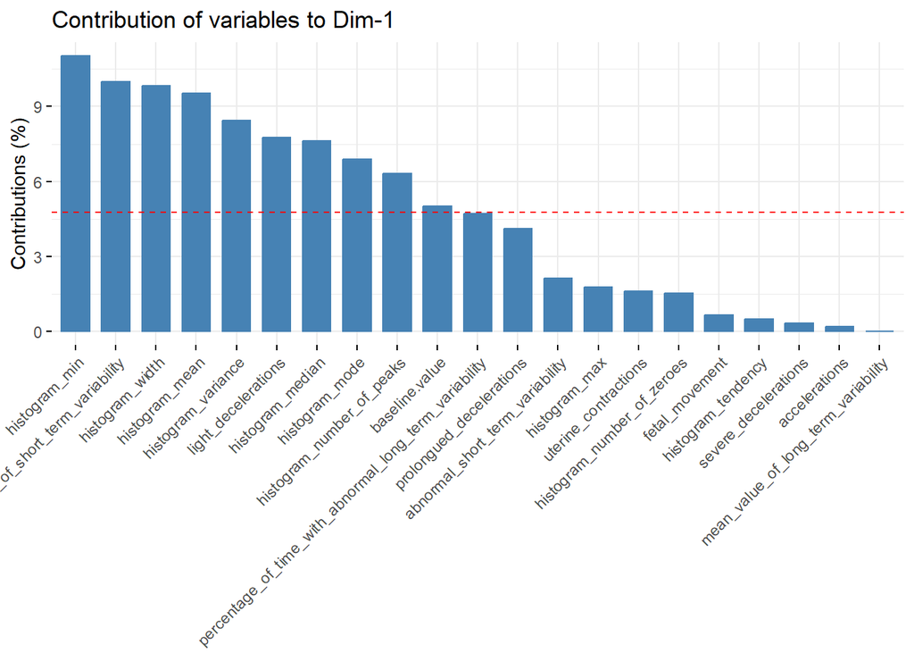

```r
fviz_contrib(pca.data,'var',axes = 1)
```

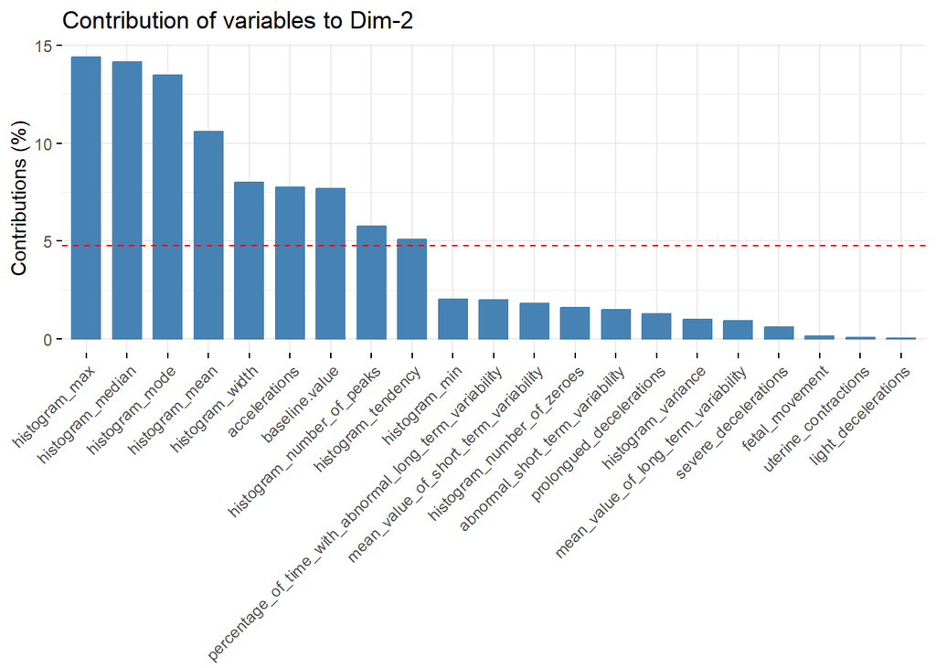

```r
fviz_contrib(pca.data,'var',axes = 2)
```

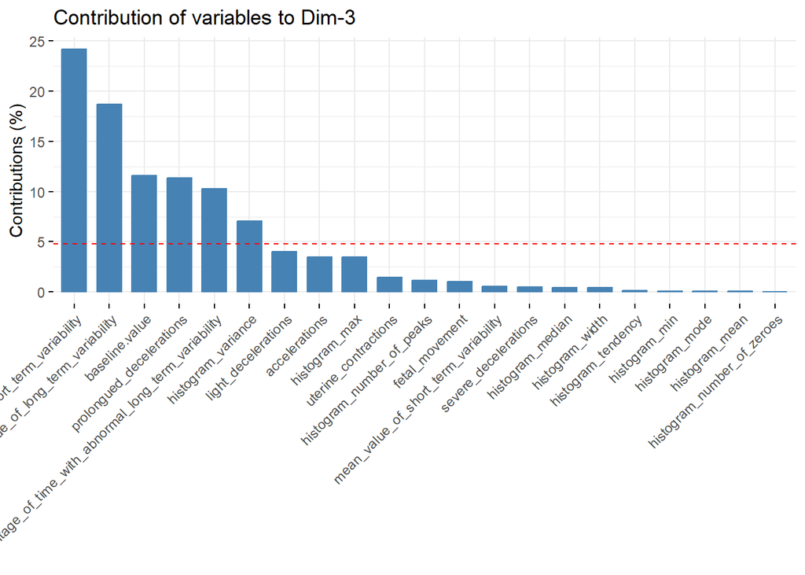

```r
fviz_contrib(pca.data,'var',axes = 3)
```

Study of individuals

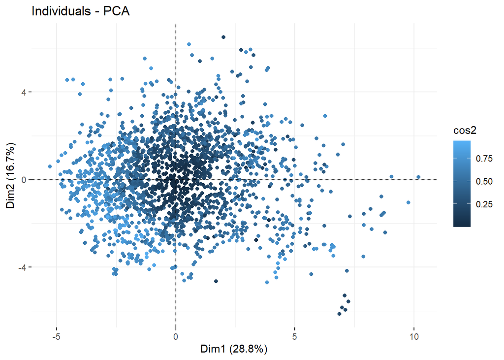

```r
fviz_pca_ind(pca.data,col.ind = 'cos2',geom = 'point')
```

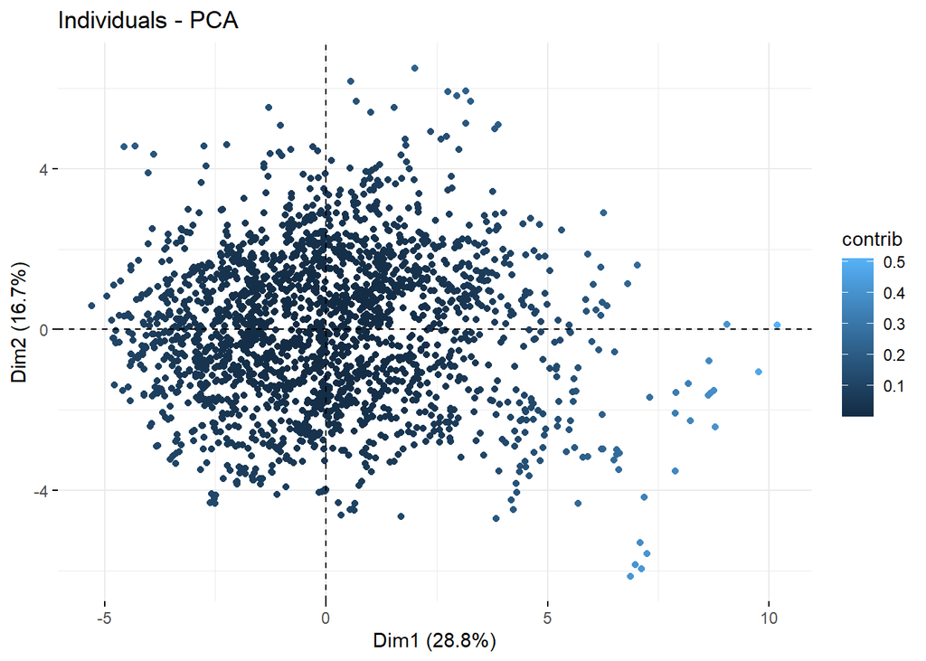

```r
fviz_pca_ind(pca.data,geom.ind = "point", repel = TRUE,col.ind = "contrib")
```

Logistic Regression

```r
colnames(data)
```

```
##  [1] "baseline.value"
##  [2] "accelerations"
##  [3] "fetal_movement"
##  [4] "uterine_contractions"
##  [5] "light_decelerations"
##  [6] "severe_decelerations"
##  [7] "prolongued_decelerations"
##  [8] "abnormal_short_term_variability"
##  [9] "mean_value_of_short_term_variability"
## [10] "percentage_of_time_with_abnormal_long_term_variability"
## [11] "mean_value_of_long_term_variability"
## [12] "histogram_width"
## [13] "histogram_min"
## [14] "histogram_max"
## [15] "histogram_number_of_peaks"
## [16] "histogram_number_of_zeroes"
## [17] "histogram_mode"
## [18] "histogram_mean"
## [19] "histogram_median"
## [20] "histogram_variance"
## [21] "histogram_tendency"
## [22] "fetal_health"
```

```r
set.seed(123)
x2<-sample(c(1:nrow(data)), 0.8*nrow(data))
training=data[x2,]
training
```

[output not shown]

[output cut: 13593 more lines]

```r
test=data[-x2,]
library(nnet)
library(MASS)

# Fit the model
model <- nnet::multinom(fetal_health ~., data = training)
# Summarize the model
summary(model)
```

```
## Call:
## nnet::multinom(formula = fetal_health ~ ., data = training)
##
## Coefficients:
##   (Intercept) baseline.value accelerations fetal_movement uterine_contractions
## 2   -4.965744      -1.306230     -3.991858      0.6153827           -0.9100256
## 3  -12.921966       2.870268     -4.695178      1.2579793           -1.2315803
##   light_decelerations severe_decelerations prolongued_decelerations
## 2         -0.04489286           -0.4580468                 1.586672
## 3         -0.05558864            0.1977228                 1.797827
##   abnormal_short_term_variability mean_value_of_short_term_variability
## 2                        1.584666                           -0.1700008
## 3                        3.924778                           -1.3526409
##   percentage_of_time_with_abnormal_long_term_variability
## 2                                              0.4911341
## 3                                              1.3776523
##   mean_value_of_long_term_variability histogram_width histogram_min
## 2                           0.0458113     -0.02130798     0.3587119
## 3                           0.5076429      0.25828366     0.3636190
##   histogram_max histogram_number_of_peaks histogram_number_of_zeroes
## 2     0.5446631                 0.3979014                 -0.0733855
## 3     1.1597226                -1.4076902                  0.4201034
##   histogram_mode histogram_mean histogram_median histogram_variance
## 2     -1.1005948       4.098529       -0.2163535           1.145881
## 3     -0.1662879      -1.388837       -3.5721852           2.309764
##   histogram_tendency
## 2          0.1058317
## 3          0.2464605
##
## Std. Errors:
##   (Intercept) baseline.value accelerations fetal_movement uterine_contractions
## 2   0.6895551      0.3786024     0.5113511      0.1350544            0.1411021
## 3   1.7769802      0.7454864     1.9428766      0.2645274            0.2886610
##   light_decelerations severe_decelerations prolongued_decelerations
## 2           0.3467034            9.8455592                0.2932964
## 3           0.4246645            0.1971076                0.3624868
##   abnormal_short_term_variability mean_value_of_short_term_variability
## 2                       0.2153812                            0.2958909
## 3                       0.5023837                            0.5258022
##   percentage_of_time_with_abnormal_long_term_variability
## 2                                              0.1319545
## 3                                              0.2302006
##   mean_value_of_long_term_variability histogram_width histogram_min
## 2                           0.2298437       0.1027764     0.1876080
## 3                           0.5014561       0.2083202     0.3259982
##   histogram_max histogram_number_of_peaks histogram_number_of_zeroes
## 2     0.2578297                 0.1876464                  0.1200877
## 3     0.3888372                 0.4902311                  0.3427936
##   histogram_mode histogram_mean histogram_median histogram_variance
## 2      0.5792938      1.1620491         1.130094          0.3046088
## 3      0.8774895      0.9059481         1.384057          0.4144542
##   histogram_tendency
## 2          0.1807314
## 3          0.2997143
##
## Residual Deviance: 690.5007
## AIC: 774.5007
```

```r
modele.backward <- stepAIC(model, ~. , trace = TRUE, data = training, direction = "backward")
```

```
## Start:  AIC=774.5
## fetal_health ~ baseline.value + accelerations + fetal_movement +
##     uterine_contractions + light_decelerations + severe_decelerations +
##     prolongued_decelerations + abnormal_short_term_variability +
##     mean_value_of_short_term_variability + percentage_of_time_with_abnormal_long_term_variability +
##     mean_value_of_long_term_variability + histogram_width + histogram_min +
##     histogram_max + histogram_number_of_peaks + histogram_number_of_zeroes +
##     histogram_mode + histogram_mean + histogram_median + histogram_variance +
##     histogram_tendency
##
##
## Step:  AIC=774.5
## fetal_health ~ baseline.value + accelerations + fetal_movement +
##     uterine_contractions + light_decelerations + severe_decelerations +
##     prolongued_decelerations + abnormal_short_term_variability +
##     mean_value_of_short_term_variability + percentage_of_time_with_abnormal_long_term_variability +
##     mean_value_of_long_term_variability + histogram_width + histogram_min +
##     histogram_number_of_peaks + histogram_number_of_zeroes +
##     histogram_mode + histogram_mean + histogram_median + histogram_variance +
##     histogram_tendency
##
##                                                          Df    AIC
## - light_decelerations                                     2 770.53
## - histogram_tendency                                      2 771.27
## - mean_value_of_long_term_variability                     2 771.52
## - severe_decelerations                                    2 771.96
## - histogram_number_of_zeroes                              2 772.40
## - histogram_mode                                          2 773.75
## <none>                                                      774.50
## - mean_value_of_short_term_variability                    2 777.13
## - histogram_median                                        2 778.14
## - histogram_min                                           2 779.32
## - histogram_width                                         2 780.84
## - histogram_number_of_peaks                               2 788.54
## - fetal_movement                                          2 796.66
## - histogram_mean                                          2 800.02
## - baseline.value                                          2 811.09
## - histogram_variance                                      2 811.28
## - percentage_of_time_with_abnormal_long_term_variability  2 813.59
## - prolongued_decelerations                                2 815.86
```

[output cut: 155 more lines]

```
## <none>                                                      760.97
## - mean_value_of_short_term_variability                    2 763.73
## - histogram_min                                           2 766.79
## - histogram_width                                         2 770.50
## - histogram_mode                                          2 771.84
## - fetal_movement                                          2 783.75
## - histogram_number_of_peaks                               2 784.12
## - histogram_variance                                      2 800.31
## - baseline.value                                          2 803.01
## - percentage_of_time_with_abnormal_long_term_variability  2 804.63
## - histogram_mean                                          2 813.20
## - uterine_contractions                                    2 814.66
## - prolongued_decelerations                                2 839.53
## - abnormal_short_term_variability                         2 890.62
## - accelerations                                           2 932.78
```

```r
library(magrittr)
test2=test[,-22]
#predictions <- predict(selected_model, newdata = test_data, type = "class")
predicted.classes <- modele.backward %>% predict(test2)
head(predicted.classes)
```

```
## [1] 1 1 1 3 2 3
## Levels: 1 2 3
```

```r
table_pred <- table(predicted.classes)
print(table_pred)
```

```
## predicted.classes
##   1   2   3
## 335  53  38
```

```r
table(test$fetal_health)
```

```
##
##   1   2   3
## 325  59  42
```

```r
accuracyLG <- sum(as.character(predicted.classes) == as.character(test$fetal_health)) / length(predicted.classes)
accuracyLG
```

```
## [1] 0.899061
```

Decision Tree

```r
set.seed(123)
library(rpart)
library(rpart.plot)
Tree <- rpart(fetal_health ~., data = training, method = "class")
TC=Tree$cptable
which.min(TC[,4])# l'erreur minimale
```

```
## 7
## 7
```

```r
optcp=TC[which.min(TC[,4]),1]# optimal CP ( la valeur de CP qui correspond à l'erreur minimale)
opnsplit=TC[which.min(TC[,4]),2] # Nb de split(divisions) optimal
opnsplit
```

```
## [1] 7
```

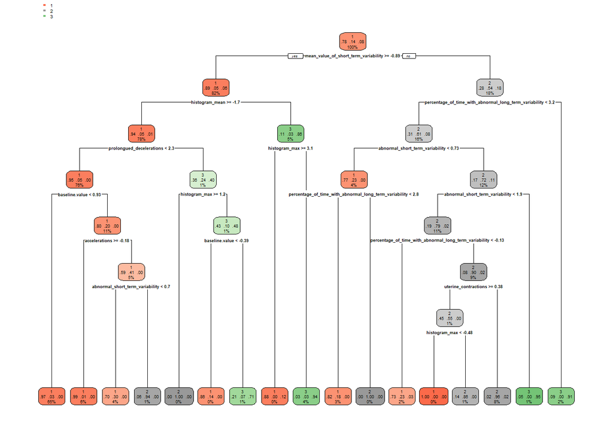

```r
#TOptimal <- rpart(survived~., data=ptitanic, cp=optcp, control=rpart.control(minsplit =opnsplit ))# arbre optimal
TOptimale<-rpart(fetal_health~.,data=training, cp=optcp, control=rpart.control(minsplit =opnsplit ))
rpart.plot(TOptimale)
```

```r
#pred=predict(TOptimal,test,type ="vector")
#pred
#table(pred)# les classes prédites
pred=predict(TOptimale,test2, type = "class")
table(test$fetal_health)# les classes réelles
```

```
##
##   1   2   3
## 325  59  42
```

```r
table_pred <- table(pred)
print(table_pred)
```

```
## pred
##   1   2   3
## 341  40  45
```

```r
library(caret)
TC2 <- confusionMatrix(pred, test$fetal_health)
accuracy <- TC2$overall['Accuracy']

print(TC2$table)
```

```
##           Reference
## Prediction   1   2   3
##          1 316  23   2
##          2   4  36   0
##          3   5   0  40
```

```r
print(accuracy)
```

```
##  Accuracy
## 0.9201878
```

```r
#TC2=table(test$fetal_health,table_pred)# confusion matrix ( Y réel vs Y prédit )
#accuracy <- sum(pred == (test$fetal_health)) / length(pred)
#accuracy
```

Random Forest

```r
set.seed(123)
library(randomForest)
modelRF <- randomForest(fetal_health ~ ., data = training)
predictForest = predict(modelRF, newdata = test2)
table(test$fetal_health, predictForest)
```

```
##    predictForest
##       1   2   3
##   1 318   6   1
##   2  12  46   1
##   3   1   1  40
```

```r
accuracyRF <- sum(as.character(predictForest) == as.character(test$fetal_health)) / length(predictForest)
accuracyRF
```

```
## [1] 0.9483568
```

```r
#library(caret)
#TC2 <- confusionMatrix(predictForest, test$fetal_health)
#accuracy <- TC2$overall['Accuracy']

#print(TC2$table)
#print(accuracy)
```

k-Means

```r
set.seed(123)
fetal_clust <- kmeans(training[,-22], centers = 3)
summary(fetal_clust)
```

```
##              Length Class  Mode
## cluster      1700   -none- numeric
## centers        63   -none- numeric
## totss           1   -none- numeric
## withinss        3   -none- numeric
## tot.withinss    1   -none- numeric
## betweenss       1   -none- numeric
## size            3   -none- numeric
## iter            1   -none- numeric
## ifault          1   -none- numeric
```

```r
cluster_assignments <-fetal_clust$cluster#Cluster number for each of the observations
head(cluster_assignments, 4)
```

```
##  526  195 1842 1142
##    1    2    1    3
```

```r
actual_labels <- training$fetal_health
classification_accuracy <- sum(cluster_assignments == actual_labels) / length(actual_labels)
print(classification_accuracy)
```

```
## [1] 0.4929412
```

Modele comparison

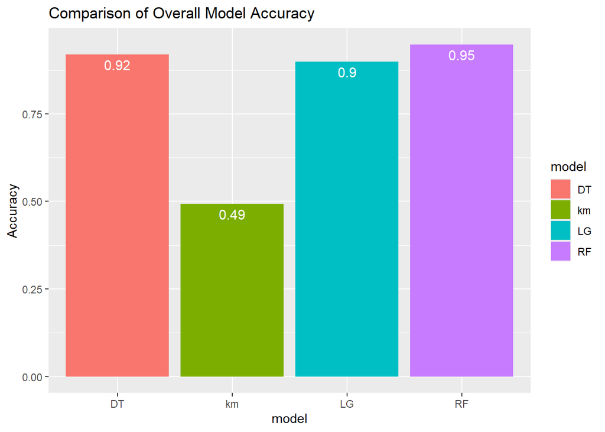

```r
all_accuracies <- as.data.frame(rbind(LG = accuracyLG, DT = accuracy, RF = accuracyRF, km=classification_accuracy ))
all_accuracies$model <- rownames(all_accuracies)
ggplot(all_accuracies, aes(x = model, y = Accuracy, fill = model)) +
  geom_bar(stat="identity") +
  ggtitle('Comparison of Overall Model Accuracy') +
  geom_text(aes(label = round(Accuracy,2)) ,
            colour = "white", size = 4,
            vjust = 1.5, position = position_dodge(.9))
```